# Racial Wealth Gap

# Introduction

Over the past 50 years, the racial wealth gap between Black and White families in the United States has not improved. The gap remains very large, mainly because of ongoing inequality in wealth, income, education, and other areas. These gaps continue because of historical and systemic racism built into American institutions and policies.

This analysis will explore the differences in wealth trends between Black and White families from 1963 to 2016 and highlight how these gaps have changed over time.

Data can be found in this [Github Repo](https://github.com/rfordatascience/tidytuesday/tree/master/data/2021/2021-02-09).

# Exploratory Data Analysis (EDA)

## Family Wealth

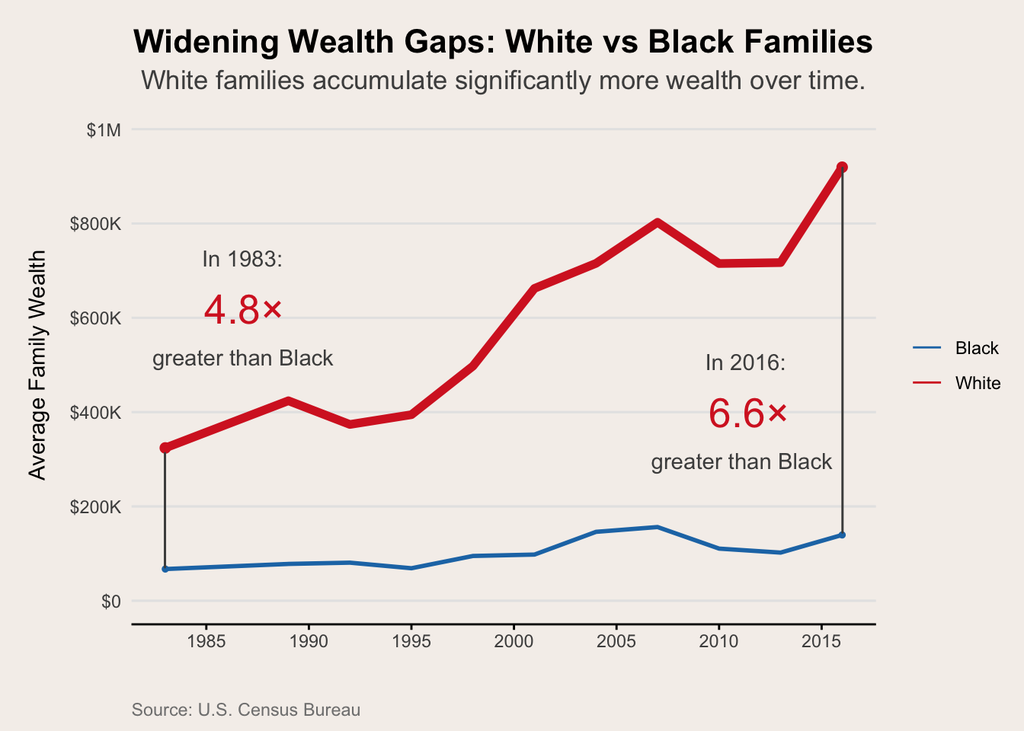

The data clearly shows a long-standing and large racial wealth gap in the United States over the past 30 years. White families have consistently had more wealth than Black families during this entire period.

In 1983, White families had about 4.8 times more wealth than Black families. By 2016, even after decades of economic growth and policy changes, this gap had grown larger, with White families now having 6.6 times more wealth than Black families. This shows economic inequality between races has actually gotten worse, not better.

While all groups saw some increase in wealth during this time, the increases were extremely uneven. White family wealth rose from about $324,000 in 1983 to nearly $930,000 in 2016—an increase of over $600,000. Black family wealth grew from around $67,000 to only $140,000, gaining just $73,000. For every dollar Black families gained, White families gained more than eight dollars.

The financial crisis of 2008 harmed all families, but White families recovered faster and more completely. By 2016, their wealth not only recovered but surpassed pre-crisis levels, while Black families struggled to catch up.

This visualization illustrates clearly how economic growth has largely benefited White families. It suggests there are larger problems within the economic system that continue to limit financial opportunity for Black Americans, causing this wealth gap to grow rather than shrink over time.

## Lifetime Wealth

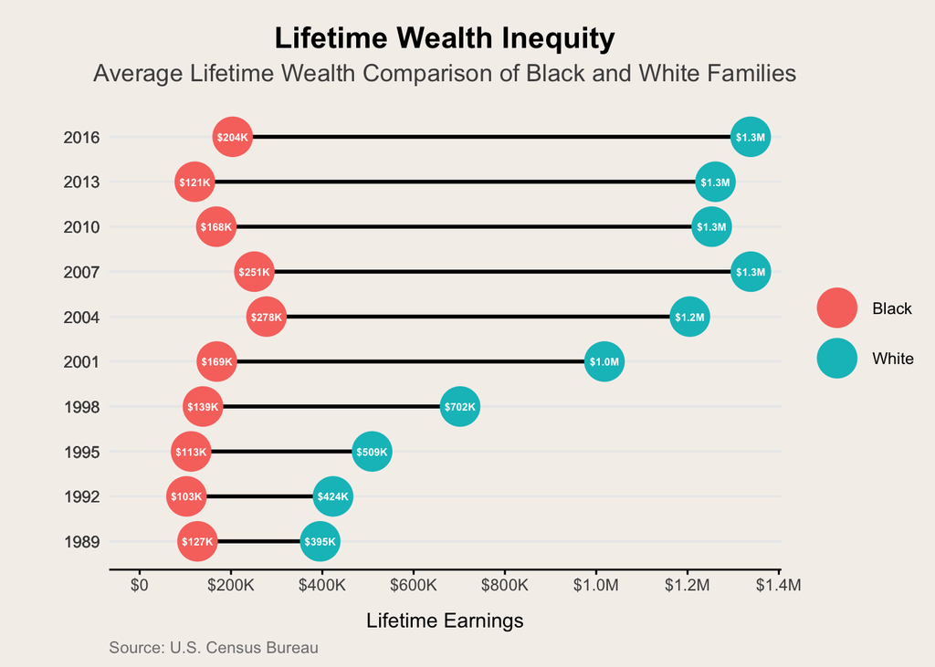

## Home Ownership

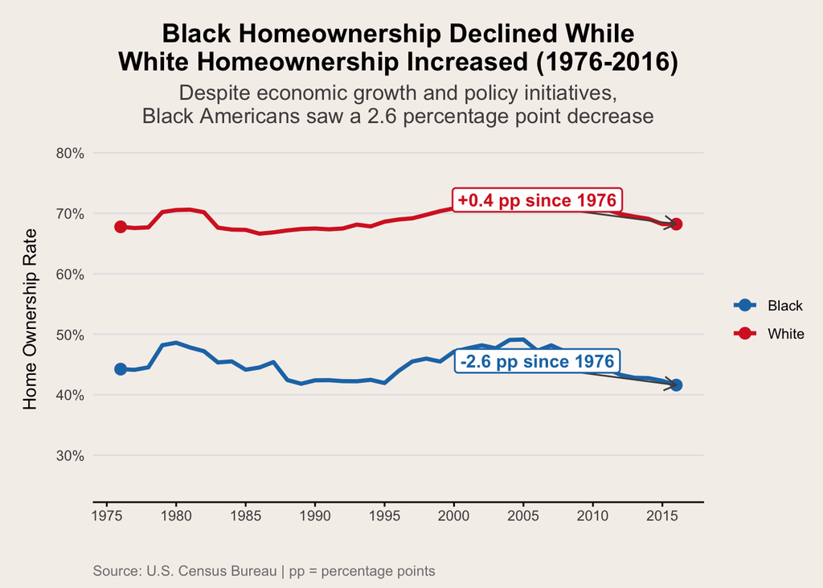

This visualization shows a troubling gap in homeownership trends between racial groups. Despite 40 years of economic growth and housing policies, homeownership among Black Americans actually declined by 2.6 percentage points from 1976 to 2016.

This decline is very different from White Americans, who saw a small 0.4 percentage point increase (from already high rates). This widening gap clearly shows that housing opportunities—and the wealth they create—are not shared equally.

This trend matters because homeownership is the main way most American families build wealth. Declining Black homeownership contributes directly to the wider wealth gap we’ve discussed.

## Retirement

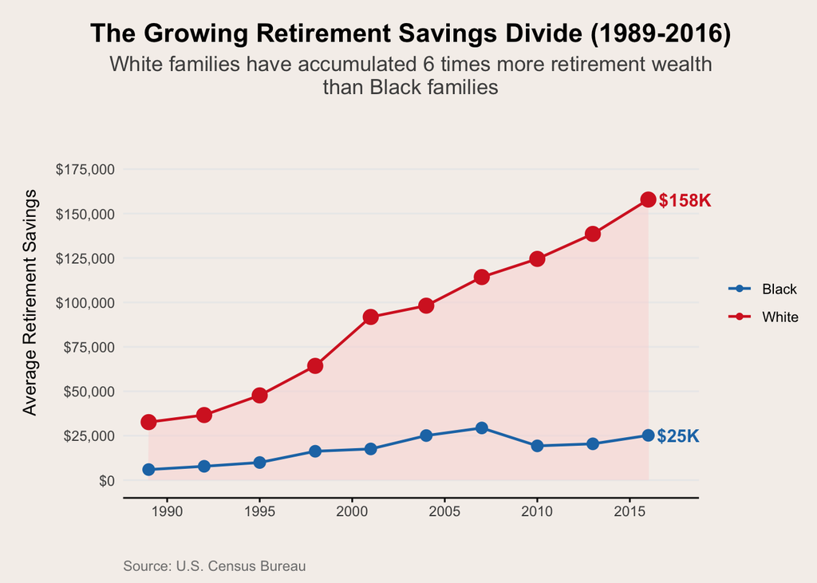

This visualization shows a major racial gap in retirement savings, which has grown significantly between 1989 and 2016. White families have built around $158,000 in retirement savings, about 6 times more than Black ($25,000) families.

This $133,000 gap means years of difference in retirement security. All groups started at lower levels in 1989, but White families’ savings grew rapidly as retirement savings shifted from company pensions to individual retirement accounts. Black families, however, saw only very small improvements during this period.

# Summary of Findings

My analysis of racial economic disparities across multiple dimensions—total wealth, lifetime earnings, homeownership, and retirement savings—reveals a troubling pattern of persistent and often widening gaps between White Americans and racial minorities, particularly Black Americans.

# Systemic Patterns and Implications

These disparities are not isolated phenomena but interconnected manifestations of systemic inequalities. Several consistent patterns emerge:

1. **Compounding Disadvantages:** Initial disparities in income and opportunity compound over time through reduced investment returns, homeownership barriers, and limited retirement savings access.
2. **Crisis Vulnerability:** Economic downturns like the 2008 financial crisis disproportionately impact minorities, with White Americans recovering more quickly and completely.
3. **Intergenerational Effects:** These gaps perpetuate across generations as reduced wealth limits educational opportunities and financial support for children.
4. **Policy Failure:** Despite decades of economic growth and anti-discrimination policies, racial economic gaps have persisted or worsened, suggesting current approaches are insufficient.

The combined effect of these disparities creates a comprehensive system of economic disadvantage that extends beyond individual dimensions. Without significant structural intervention, these gaps will likely continue to widen, threatening America’s promise of equal opportunity and economic mobility for all citizens.